# Risk Factor Analysis

## Outcome Variable

**Outcome Variable:** ever_stunted

## Predictor Variables

**Intervention Variable:** mbmi

**Adjustment Set:**

unadjusted

## Stratifying Variables

The analysis was stratified on these variable(s):

- agecat
- studyid

The following strata were considered:

- agecat: 12 months, studyid: ki1000304b-SAS-CompFeed
- agecat: 12 months, studyid: ki1017093-NIH-Birth
- agecat: 12 months, studyid: ki1017093c-NIH-Crypto
- agecat: 12 months, studyid: ki1066203-TanzaniaChild2
- agecat: 12 months, studyid: ki1112895-iLiNS-Zinc
- agecat: 12 months, studyid: ki1119695-PROBIT
- agecat: 12 months, studyid: ki1126311-ZVITAMBO
- agecat: 12 months, studyid: ki1148112-LCNI-5
- agecat: 12 months, studyid: kiGH5241-JiVitA-3
- agecat: 18 months, studyid: ki1000304b-SAS-CompFeed
- agecat: 18 months, studyid: ki1017093-NIH-Birth
- agecat: 18 months, studyid: ki1017093c-NIH-Crypto
- agecat: 18 months, studyid: ki1066203-TanzaniaChild2
- agecat: 18 months, studyid: ki1112895-iLiNS-Zinc
- agecat: 18 months, studyid: ki1119695-PROBIT
- agecat: 18 months, studyid: ki1126311-ZVITAMBO
- agecat: 18 months, studyid: ki1148112-LCNI-5
- agecat: 18 months, studyid: kiGH5241-JiVitA-3
- agecat: 24 months, studyid: ki1000304b-SAS-CompFeed
- agecat: 24 months, studyid: ki1017093-NIH-Birth
- agecat: 24 months, studyid: ki1017093c-NIH-Crypto
- agecat: 24 months, studyid: ki1066203-TanzaniaChild2
- agecat: 24 months, studyid: ki1112895-iLiNS-Zinc
- agecat: 24 months, studyid: ki1119695-PROBIT
- agecat: 24 months, studyid: ki1126311-ZVITAMBO
- agecat: 24 months, studyid: ki1148112-LCNI-5
- agecat: 24 months, studyid: kiGH5241-JiVitA-3
- agecat: 3 months, studyid: ki1000304b-SAS-CompFeed
- agecat: 3 months, studyid: ki1017093-NIH-Birth
- agecat: 3 months, studyid: ki1017093c-NIH-Crypto
- agecat: 3 months, studyid: ki1066203-TanzaniaChild2
- agecat: 3 months, studyid: ki1119695-PROBIT
- agecat: 3 months, studyid: ki1126311-ZVITAMBO
- agecat: 3 months, studyid: kiGH5241-JiVitA-3
- agecat: 6 months, studyid: ki1000304b-SAS-CompFeed
- agecat: 6 months, studyid: ki1017093-NIH-Birth
- agecat: 6 months, studyid: ki1017093c-NIH-Crypto
- agecat: 6 months, studyid: ki1066203-TanzaniaChild2
- agecat: 6 months, studyid: ki1119695-PROBIT
- agecat: 6 months, studyid: ki1126311-ZVITAMBO
- agecat: 6 months, studyid: ki1148112-LCNI-5
- agecat: 6 months, studyid: kiGH5241-JiVitA-3

## Methods Detail

# Results Detail

## Results Plots

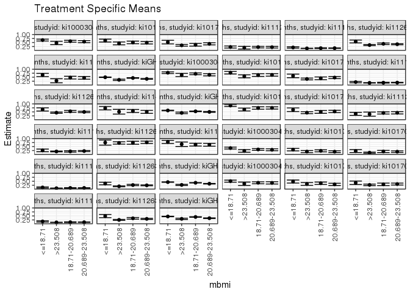

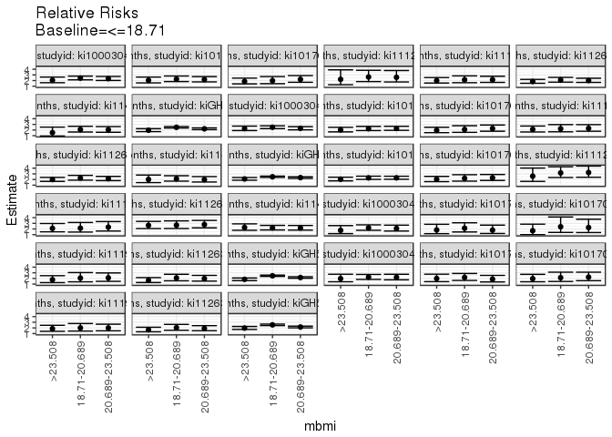

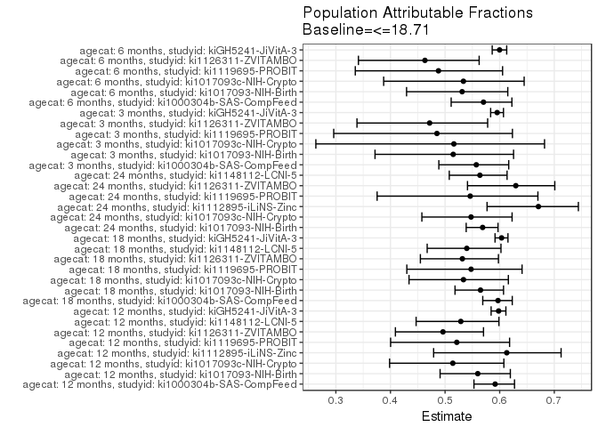

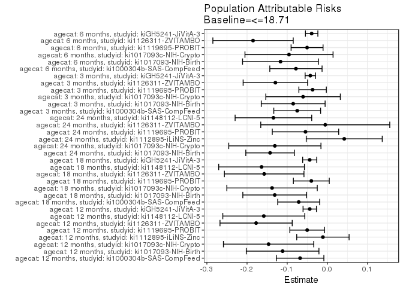

## Data Summary

| agecat | studyid | A | n | nA | nAY0 | nAY1 |
| --- | --- | --- | --- | --- | --- | --- |
| 12 months | ki1000304b-SAS-CompFeed | <=18.71 | 827 | 250 | 87 | 163 |
| 12 months | ki1000304b-SAS-CompFeed | >23.508 | 827 | 87 | 46 | 41 |
| 12 months | ki1000304b-SAS-CompFeed | 18.71-20.689 | 827 | 281 | 118 | 163 |
| 12 months | ki1000304b-SAS-CompFeed | 20.689-23.508 | 827 | 209 | 93 | 116 |
| 12 months | ki1017093-NIH-Birth | <=18.71 | 541 | 111 | 42 | 69 |
| 12 months | ki1017093-NIH-Birth | >23.508 | 541 | 117 | 65 | 52 |
| 12 months | ki1017093-NIH-Birth | 18.71-20.689 | 541 | 148 | 73 | 75 |
| 12 months | ki1017093-NIH-Birth | 20.689-23.508 | 541 | 165 | 85 | 80 |
| 12 months | ki1017093c-NIH-Crypto | <=18.71 | 729 | 76 | 36 | 40 |
| 12 months | ki1017093c-NIH-Crypto | >23.508 | 729 | 299 | 202 | 97 |
| 12 months | ki1017093c-NIH-Crypto | 18.71-20.689 | 729 | 131 | 84 | 47 |
| 12 months | ki1017093c-NIH-Crypto | 20.689-23.508 | 729 | 223 | 130 | 93 |
| 12 months | ki1066203-TanzaniaChild2 | <=18.71 | 488 | 5 | 5 | 0 |
| 12 months | ki1066203-TanzaniaChild2 | >23.508 | 488 | 309 | 215 | 94 |
| 12 months | ki1066203-TanzaniaChild2 | 18.71-20.689 | 488 | 44 | 31 | 13 |
| 12 months | ki1066203-TanzaniaChild2 | 20.689-23.508 | 488 | 130 | 79 | 51 |
| 12 months | ki1112895-iLiNS-Zinc | <=18.71 | 778 | 155 | 121 | 34 |
| 12 months | ki1112895-iLiNS-Zinc | >23.508 | 778 | 80 | 66 | 14 |
| 12 months | ki1112895-iLiNS-Zinc | 18.71-20.689 | 778 | 292 | 230 | 62 |
| 12 months | ki1112895-iLiNS-Zinc | 20.689-23.508 | 778 | 251 | 199 | 52 |
| 12 months | ki1119695-PROBIT | <=18.71 | 6670 | 319 | 258 | 61 |
| 12 months | ki1119695-PROBIT | >23.508 | 6670 | 3491 | 3031 | 460 |
| 12 months | ki1119695-PROBIT | 18.71-20.689 | 6670 | 865 | 739 | 126 |
| 12 months | ki1119695-PROBIT | 20.689-23.508 | 6670 | 1995 | 1702 | 293 |
| 12 months | ki1126311-ZVITAMBO | <=18.71 | 2069 | 117 | 51 | 66 |
| 12 months | ki1126311-ZVITAMBO | >23.508 | 2069 | 841 | 554 | 287 |
| 12 months | ki1126311-ZVITAMBO | 18.71-20.689 | 2069 | 367 | 213 | 154 |
| 12 months | ki1126311-ZVITAMBO | 20.689-23.508 | 2069 | 744 | 451 | 293 |
| 12 months | ki1148112-LCNI-5 | <=18.71 | 401 | 86 | 31 | 55 |
| 12 months | ki1148112-LCNI-5 | >23.508 | 401 | 47 | 34 | 13 |

[output cut: 150 more lines]

## Results Table

### Parameter: TSM

| agecat | studyid | intervention_level | baseline_level | estimate | ci_lower | ci_upper |
| --- | --- | --- | --- | --- | --- | --- |
| 12 months | ki1000304b-SAS-CompFeed | <=18.71 | NA | 0.6520000 | 0.5929181 | 0.7110819 |
| 12 months | ki1000304b-SAS-CompFeed | >23.508 | NA | 0.4712644 | 0.3663095 | 0.5762193 |
| 12 months | ki1000304b-SAS-CompFeed | 18.71-20.689 | NA | 0.5800712 | 0.5223299 | 0.6378124 |
| 12 months | ki1000304b-SAS-CompFeed | 20.689-23.508 | NA | 0.5550239 | 0.4876081 | 0.6224397 |
| 12 months | ki1017093-NIH-Birth | <=18.71 | NA | 0.6216216 | 0.5313160 | 0.7119272 |
| 12 months | ki1017093-NIH-Birth | >23.508 | NA | 0.4444444 | 0.3543227 | 0.5345661 |
| 12 months | ki1017093-NIH-Birth | 18.71-20.689 | NA | 0.5067568 | 0.4261355 | 0.5873780 |
| 12 months | ki1017093-NIH-Birth | 20.689-23.508 | NA | 0.4848485 | 0.4085215 | 0.5611755 |
| 12 months | ki1017093c-NIH-Crypto | <=18.71 | NA | 0.5263158 | 0.4139829 | 0.6386487 |
| 12 months | ki1017093c-NIH-Crypto | >23.508 | NA | 0.3244147 | 0.2713139 | 0.3775155 |
| 12 months | ki1017093c-NIH-Crypto | 18.71-20.689 | NA | 0.3587786 | 0.2765870 | 0.4409703 |
| 12 months | ki1017093c-NIH-Crypto | 20.689-23.508 | NA | 0.4170404 | 0.3522811 | 0.4817996 |
| 12 months | ki1112895-iLiNS-Zinc | <=18.71 | NA | 0.2193548 | 0.1541677 | 0.2845420 |
| 12 months | ki1112895-iLiNS-Zinc | >23.508 | NA | 0.1750000 | 0.0916840 | 0.2583160 |
| 12 months | ki1112895-iLiNS-Zinc | 18.71-20.689 | NA | 0.2123288 | 0.1653920 | 0.2592655 |
| 12 months | ki1112895-iLiNS-Zinc | 20.689-23.508 | NA | 0.2071713 | 0.1570012 | 0.2573414 |
| 12 months | ki1119695-PROBIT | <=18.71 | NA | 0.1912226 | 0.1480638 | 0.2343814 |
| 12 months | ki1119695-PROBIT | >23.508 | NA | 0.1317674 | 0.1205465 | 0.1429883 |
| 12 months | ki1119695-PROBIT | 18.71-20.689 | NA | 0.1456647 | 0.1221541 | 0.1691754 |
| 12 months | ki1119695-PROBIT | 20.689-23.508 | NA | 0.1468672 | 0.1313333 | 0.1624010 |
| 12 months | ki1126311-ZVITAMBO | <=18.71 | NA | 0.5641026 | 0.4742291 | 0.6539760 |
| 12 months | ki1126311-ZVITAMBO | >23.508 | NA | 0.3412604 | 0.3092084 | 0.3733124 |
| 12 months | ki1126311-ZVITAMBO | 18.71-20.689 | NA | 0.4196185 | 0.3691170 | 0.4701200 |
| 12 months | ki1126311-ZVITAMBO | 20.689-23.508 | NA | 0.3938172 | 0.3587003 | 0.4289341 |
| 12 months | ki1148112-LCNI-5 | <=18.71 | NA | 0.6395349 | 0.5379323 | 0.7411375 |
| 12 months | ki1148112-LCNI-5 | >23.508 | NA | 0.2765957 | 0.1485531 | 0.4046384 |
| 12 months | ki1148112-LCNI-5 | 18.71-20.689 | NA | 0.4736842 | 0.3887208 | 0.5586477 |
| 12 months | ki1148112-LCNI-5 | 20.689-23.508 | NA | 0.4592593 | 0.3750913 | 0.5434272 |
| 12 months | kiGH5241-JiVitA-3 | <=18.71 | NA | 0.4958177 | 0.4791739 | 0.5124615 |
| 12 months | kiGH5241-JiVitA-3 | >23.508 | NA | 0.3347639 | 0.2919152 | 0.3776127 |

[output cut: 102 more lines]

### Parameter: E(Y)

| agecat | studyid | intervention_level | baseline_level | estimate | ci_lower | ci_upper |
| --- | --- | --- | --- | --- | --- | --- |
| 12 months | ki1000304b-SAS-CompFeed | NA | NA | 0.5840387 | 0.5803333 | 0.5877441 |
| 12 months | ki1017093-NIH-Birth | NA | NA | 0.5101664 | 0.5050487 | 0.5152840 |
| 12 months | ki1017093c-NIH-Crypto | NA | NA | 0.3799726 | 0.3753785 | 0.3845666 |
| 12 months | ki1112895-iLiNS-Zinc | NA | NA | 0.2082262 | 0.2073799 | 0.2090725 |
| 12 months | ki1119695-PROBIT | NA | NA | 0.1409295 | 0.1406090 | 0.1412501 |
| 12 months | ki1126311-ZVITAMBO | NA | NA | 0.3866602 | 0.3843677 | 0.3889528 |
| 12 months | ki1148112-LCNI-5 | NA | NA | 0.4812968 | 0.4712722 | 0.4913214 |
| 12 months | kiGH5241-JiVitA-3 | NA | NA | 0.4519219 | 0.4509111 | 0.4529327 |
| 18 months | ki1000304b-SAS-CompFeed | NA | NA | 0.7096370 | 0.7058600 | 0.7134141 |
| 18 months | ki1017093-NIH-Birth | NA | NA | 0.6498994 | 0.6432729 | 0.6565259 |
| 18 months | ki1017093c-NIH-Crypto | NA | NA | 0.4433566 | 0.4389890 | 0.4477243 |
| 18 months | ki1119695-PROBIT | NA | NA | 0.1533617 | 0.1530831 | 0.1536402 |
| 18 months | ki1126311-ZVITAMBO | NA | NA | 0.4943671 | 0.4918306 | 0.4969037 |
| 18 months | ki1148112-LCNI-5 | NA | NA | 0.5674847 | 0.5580783 | 0.5768910 |
| 18 months | kiGH5241-JiVitA-3 | NA | NA | 0.5437637 | 0.5427655 | 0.5447618 |
| 24 months | ki1017093-NIH-Birth | NA | NA | 0.7553191 | 0.7478061 | 0.7628322 |
| 24 months | ki1017093c-NIH-Crypto | NA | NA | 0.5015773 | 0.4972265 | 0.5059281 |
| 24 months | ki1112895-iLiNS-Zinc | NA | NA | 0.4182156 | 0.4155944 | 0.4208368 |
| 24 months | ki1119695-PROBIT | NA | NA | 0.2047550 | 0.2040132 | 0.2054968 |
| 24 months | ki1126311-ZVITAMBO | NA | NA | 0.7447368 | 0.7429732 | 0.7465005 |
| 24 months | ki1148112-LCNI-5 | NA | NA | 0.6543909 | 0.6472746 | 0.6615073 |
| 3 months | ki1000304b-SAS-CompFeed | NA | NA | 0.3300000 | 0.3263304 | 0.3336696 |
| 3 months | ki1017093-NIH-Birth | NA | NA | 0.2225755 | 0.2187858 | 0.2263652 |
| 3 months | ki1017093c-NIH-Crypto | NA | NA | 0.1602649 | 0.1575389 | 0.1629909 |
| 3 months | ki1119695-PROBIT | NA | NA | 0.0726023 | 0.0723125 | 0.0728921 |
| 3 months | ki1126311-ZVITAMBO | NA | NA | 0.2282295 | 0.2263936 | 0.2300653 |
| 3 months | kiGH5241-JiVitA-3 | NA | NA | 0.4035497 | 0.4027263 | 0.4043731 |
| 6 months | ki1000304b-SAS-CompFeed | NA | NA | 0.4260985 | 0.4221843 | 0.4300128 |
| 6 months | ki1017093-NIH-Birth | NA | NA | 0.3647913 | 0.3594505 | 0.3701321 |
| 6 months | ki1017093c-NIH-Crypto | NA | NA | 0.3070652 | 0.3042034 | 0.3099270 |
| 6 months | ki1119695-PROBIT | NA | NA | 0.1023077 | 0.1020041 | 0.1026113 |
| 6 months | ki1126311-ZVITAMBO | NA | NA | 0.3045311 | 0.3019569 | 0.3071053 |
| 6 months | kiGH5241-JiVitA-3 | NA | NA | 0.4255965 | 0.4246542 | 0.4265387 |

### Parameter: RR

| agecat | studyid | intervention_level | baseline_level | estimate | ci_lower | ci_upper |
| --- | --- | --- | --- | --- | --- | --- |
| 12 months | ki1000304b-SAS-CompFeed | >23.508 | <=18.71 | 2.060190 | 1.6198921 | 2.620163 |
| 12 months | ki1000304b-SAS-CompFeed | 18.71-20.689 | <=18.71 | 2.434350 | 2.1277597 | 2.785117 |
| 12 months | ki1000304b-SAS-CompFeed | 20.689-23.508 | <=18.71 | 2.342605 | 2.0131922 | 2.725919 |
| 12 months | ki1017093-NIH-Birth | >23.508 | <=18.71 | 2.044137 | 1.5928627 | 2.623263 |
| 12 months | ki1017093-NIH-Birth | 18.71-20.689 | <=18.71 | 2.259667 | 1.8217106 | 2.802912 |
| 12 months | ki1017093-NIH-Birth | 20.689-23.508 | <=18.71 | 2.181415 | 1.7607872 | 2.702524 |
| 12 months | ki1017093c-NIH-Crypto | >23.508 | <=18.71 | 1.852226 | 1.4154073 | 2.423853 |
| 12 months | ki1017093c-NIH-Crypto | 18.71-20.689 | <=18.71 | 1.977195 | 1.4456728 | 2.704140 |
| 12 months | ki1017093c-NIH-Crypto | 20.689-23.508 | <=18.71 | 2.208639 | 1.6962722 | 2.875770 |
| 12 months | ki1112895-iLiNS-Zinc | >23.508 | <=18.71 | 2.220637 | 1.2668912 | 3.892386 |
| 12 months | ki1112895-iLiNS-Zinc | 18.71-20.689 | <=18.71 | 2.632593 | 1.8177346 | 3.812739 |
| 12 months | ki1112895-iLiNS-Zinc | 20.689-23.508 | <=18.71 | 2.571418 | 1.7526084 | 3.772771 |
| 12 months | ki1119695-PROBIT | >23.508 | <=18.71 | 1.991880 | 1.5649420 | 2.535292 |
| 12 months | ki1119695-PROBIT | 18.71-20.689 | <=18.71 | 2.142032 | 1.6230104 | 2.827031 |
| 12 months | ki1119695-PROBIT | 20.689-23.508 | <=18.71 | 2.155544 | 1.6799936 | 2.765706 |
| 12 months | ki1126311-ZVITAMBO | >23.508 | <=18.71 | 1.831182 | 1.5219870 | 2.203190 |
| 12 months | ki1126311-ZVITAMBO | 18.71-20.689 | <=18.71 | 2.104061 | 1.7232303 | 2.569054 |
| 12 months | ki1126311-ZVITAMBO | 20.689-23.508 | <=18.71 | 2.009991 | 1.6745641 | 2.412608 |
| 12 months | ki1148112-LCNI-5 | >23.508 | <=18.71 | 1.541098 | 0.9446596 | 2.514115 |
| 12 months | ki1148112-LCNI-5 | 18.71-20.689 | <=18.71 | 2.097340 | 1.6504724 | 2.665198 |
| 12 months | ki1148112-LCNI-5 | 20.689-23.508 | <=18.71 | 2.050563 | 1.6089336 | 2.613414 |
| 12 months | kiGH5241-JiVitA-3 | >23.508 | <=18.71 | 1.964378 | 1.7209043 | 2.242297 |
| 12 months | kiGH5241-JiVitA-3 | 18.71-20.689 | <=18.71 | 2.483039 | 2.3547451 | 2.618323 |
| 12 months | kiGH5241-JiVitA-3 | 20.689-23.508 | <=18.71 | 2.214951 | 2.0680012 | 2.372342 |
| 18 months | ki1000304b-SAS-CompFeed | >23.508 | <=18.71 | 2.267948 | 1.9091150 | 2.694226 |
| 18 months | ki1000304b-SAS-CompFeed | 18.71-20.689 | <=18.71 | 2.489018 | 2.2499951 | 2.753432 |
| 18 months | ki1000304b-SAS-CompFeed | 20.689-23.508 | <=18.71 | 2.298542 | 2.0351495 | 2.596024 |
| 18 months | ki1017093-NIH-Birth | >23.508 | <=18.71 | 2.036804 | 1.6726639 | 2.480219 |
| 18 months | ki1017093-NIH-Birth | 18.71-20.689 | <=18.71 | 2.245053 | 1.9039132 | 2.647318 |
| 18 months | ki1017093-NIH-Birth | 20.689-23.508 | <=18.71 | 2.276331 | 1.9466790 | 2.661807 |

[output cut: 69 more lines]

### Parameter: PAR

| agecat | studyid | intervention_level | baseline_level | estimate | ci_lower | ci_upper |
| --- | --- | --- | --- | --- | --- | --- |
| 12 months | ki1000304b-SAS-CompFeed | <=18.71 | NA | -0.0679613 | -0.1271593 | -0.0087634 |
| 12 months | ki1017093-NIH-Birth | <=18.71 | NA | -0.1114553 | -0.2019057 | -0.0210048 |
| 12 months | ki1017093c-NIH-Crypto | <=18.71 | NA | -0.1463432 | -0.2587700 | -0.0339164 |
| 12 months | ki1112895-iLiNS-Zinc | <=18.71 | NA | -0.0111286 | -0.0763213 | 0.0540640 |
| 12 months | ki1119695-PROBIT | <=18.71 | NA | -0.0502930 | -0.0934530 | -0.0071330 |
| 12 months | ki1126311-ZVITAMBO | <=18.71 | NA | -0.1774423 | -0.2673450 | -0.0875397 |
| 12 months | ki1148112-LCNI-5 | <=18.71 | NA | -0.1582381 | -0.2603341 | -0.0561422 |
| 12 months | kiGH5241-JiVitA-3 | <=18.71 | NA | -0.0438958 | -0.0605702 | -0.0272213 |
| 18 months | ki1000304b-SAS-CompFeed | <=18.71 | NA | -0.0713547 | -0.1236307 | -0.0190787 |
| 18 months | ki1017093-NIH-Birth | <=18.71 | NA | -0.1310530 | -0.2105201 | -0.0515859 |
| 18 months | ki1017093c-NIH-Crypto | <=18.71 | NA | -0.1377244 | -0.2503006 | -0.0251482 |
| 18 months | ki1119695-PROBIT | <=18.71 | NA | -0.0399717 | -0.0846637 | 0.0047204 |
| 18 months | ki1126311-ZVITAMBO | <=18.71 | NA | -0.1573183 | -0.2563659 | -0.0582706 |
| 18 months | ki1148112-LCNI-5 | <=18.71 | NA | -0.1638586 | -0.2705750 | -0.0571423 |
| 18 months | kiGH5241-JiVitA-3 | <=18.71 | NA | -0.0440075 | -0.0615293 | -0.0264858 |
| 24 months | ki1017093-NIH-Birth | <=18.71 | NA | -0.1426400 | -0.2031033 | -0.0821767 |
| 24 months | ki1017093c-NIH-Crypto | <=18.71 | NA | -0.1307757 | -0.2455498 | -0.0160015 |
| 24 months | ki1112895-iLiNS-Zinc | <=18.71 | NA | 0.0419780 | -0.0526237 | 0.1365797 |
| 24 months | ki1119695-PROBIT | <=18.71 | NA | -0.0545043 | -0.1371765 | 0.0281679 |
| 24 months | ki1126311-ZVITAMBO | <=18.71 | NA | -0.0052632 | -0.1658715 | 0.1553452 |
| 24 months | ki1148112-LCNI-5 | <=18.71 | NA | -0.1343415 | -0.2296933 | -0.0389896 |
| 3 months | ki1000304b-SAS-CompFeed | <=18.71 | NA | -0.0751095 | -0.1333844 | -0.0168346 |
| 3 months | ki1017093-NIH-Birth | <=18.71 | NA | -0.0851168 | -0.1646089 | -0.0056247 |
| 3 months | ki1017093c-NIH-Crypto | <=18.71 | NA | -0.0605143 | -0.1532587 | 0.0322301 |
| 3 months | ki1119695-PROBIT | <=18.71 | NA | -0.0367727 | -0.0709728 | -0.0025726 |
| 3 months | ki1126311-ZVITAMBO | <=18.71 | NA | -0.1294348 | -0.2097337 | -0.0491358 |
| 3 months | kiGH5241-JiVitA-3 | <=18.71 | NA | -0.0424581 | -0.0554049 | -0.0295112 |
| 6 months | ki1000304b-SAS-CompFeed | <=18.71 | NA | -0.0782874 | -0.1433469 | -0.0132279 |
| 6 months | ki1017093-NIH-Birth | <=18.71 | NA | -0.1166902 | -0.2111610 | -0.0222194 |
| 6 months | ki1017093c-NIH-Crypto | <=18.71 | NA | -0.0955322 | -0.2051838 | 0.0141194 |
| 6 months | ki1119695-PROBIT | <=18.71 | NA | -0.0505585 | -0.0903657 | -0.0107514 |
| 6 months | ki1126311-ZVITAMBO | <=18.71 | NA | -0.1850522 | -0.2851090 | -0.0849955 |
| 6 months | kiGH5241-JiVitA-3 | <=18.71 | NA | -0.0391225 | -0.0545336 | -0.0237114 |

### Parameter: PAF

| agecat | studyid | intervention_level | baseline_level | estimate | ci_lower | ci_upper |
| --- | --- | --- | --- | --- | --- | --- |
| 12 months | ki1000304b-SAS-CompFeed | <=18.71 | NA | 0.5917048 | 0.5528793 | 0.6271589 |
| 12 months | ki1017093-NIH-Birth | <=18.71 | NA | 0.5598776 | 0.4908855 | 0.6195203 |
| 12 months | ki1017093c-NIH-Crypto | <=18.71 | NA | 0.5141950 | 0.3984064 | 0.6076977 |
| 12 months | ki1112895-iLiNS-Zinc | <=18.71 | NA | 0.6129752 | 0.4790296 | 0.7124824 |
| 12 months | ki1119695-PROBIT | <=18.71 | NA | 0.5214488 | 0.4002734 | 0.6181407 |
| 12 months | ki1126311-ZVITAMBO | <=18.71 | NA | 0.4961331 | 0.4090428 | 0.5703887 |
| 12 months | ki1148112-LCNI-5 | <=18.71 | NA | 0.5288473 | 0.4469706 | 0.5986021 |
| 12 months | kiGH5241-JiVitA-3 | <=18.71 | NA | 0.5980662 | 0.5843140 | 0.6113634 |
| 18 months | ki1000304b-SAS-CompFeed | <=18.71 | NA | 0.5969263 | 0.5690070 | 0.6230369 |
| 18 months | ki1017093-NIH-Birth | <=18.71 | NA | 0.5649039 | 0.5182233 | 0.6070614 |
| 18 months | ki1017093c-NIH-Crypto | <=18.71 | NA | 0.5337279 | 0.4339911 | 0.6158900 |
| 18 months | ki1119695-PROBIT | <=18.71 | NA | 0.5476278 | 0.4299787 | 0.6409949 |
| 18 months | ki1126311-ZVITAMBO | <=18.71 | NA | 0.5316774 | 0.4547845 | 0.5977259 |
| 18 months | ki1148112-LCNI-5 | <=18.71 | NA | 0.5397330 | 0.4672250 | 0.6023730 |
| 18 months | kiGH5241-JiVitA-3 | <=18.71 | NA | 0.6035194 | 0.5915188 | 0.6151674 |
| 24 months | ki1017093-NIH-Birth | <=18.71 | NA | 0.5687860 | 0.5386518 | 0.5969520 |
| 24 months | ki1017093c-NIH-Crypto | <=18.71 | NA | 0.5476016 | 0.4575242 | 0.6227217 |
| 24 months | ki1112895-iLiNS-Zinc | <=18.71 | NA | 0.6709591 | 0.5769015 | 0.7441070 |
| 24 months | ki1119695-PROBIT | <=18.71 | NA | 0.5460504 | 0.3755494 | 0.6699976 |
| 24 months | ki1126311-ZVITAMBO | <=18.71 | NA | 0.6295299 | 0.5410609 | 0.7009448 |
| 24 months | ki1148112-LCNI-5 | <=18.71 | NA | 0.5638086 | 0.5076815 | 0.6135370 |
| 3 months | ki1000304b-SAS-CompFeed | <=18.71 | NA | 0.5571812 | 0.4885985 | 0.6165664 |
| 3 months | ki1017093-NIH-Birth | <=18.71 | NA | 0.5148855 | 0.3717102 | 0.6254339 |
| 3 months | ki1017093c-NIH-Crypto | <=18.71 | NA | 0.5161139 | 0.2633669 | 0.6821406 |
| 3 months | ki1119695-PROBIT | <=18.71 | NA | 0.4851052 | 0.2960808 | 0.6233707 |
| 3 months | ki1126311-ZVITAMBO | <=18.71 | NA | 0.4717106 | 0.3386792 | 0.5779813 |
| 3 months | kiGH5241-JiVitA-3 | <=18.71 | NA | 0.5953789 | 0.5834559 | 0.6069606 |
| 6 months | ki1000304b-SAS-CompFeed | <=18.71 | NA | 0.5703510 | 0.5111529 | 0.6223804 |
| 6 months | ki1017093-NIH-Birth | <=18.71 | NA | 0.5312302 | 0.4294773 | 0.6148355 |
| 6 months | ki1017093c-NIH-Crypto | <=18.71 | NA | 0.5335994 | 0.3875471 | 0.6448225 |
| 6 months | ki1119695-PROBIT | <=18.71 | NA | 0.4879141 | 0.3355850 | 0.6053189 |
| 6 months | ki1126311-ZVITAMBO | <=18.71 | NA | 0.4631416 | 0.3413365 | 0.5624216 |
| 6 months | kiGH5241-JiVitA-3 | <=18.71 | NA | 0.5998095 | 0.5863109 | 0.6128677 |